# final

# Elastic net model

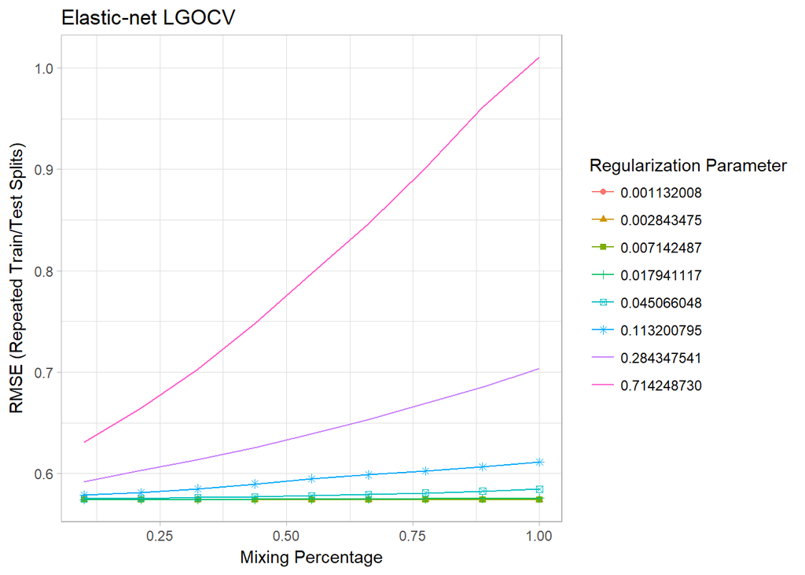

```r
set.seed(1)
glmnetmodel2 <- train(
  life_ladder~., data = df, method = "glmnet",
  preProcess=c("center", "scale"),
  trControl = trainControl("LGOCV", number = 10)
  ,tuneLength = 9
  )
ggplot(glmnetmodel2)+
  theme_light()+
  labs(title="Elastic-net LGOCV")
```

```r
glmnetmodel2$bestTune
```

```
##     alpha      lambda
## 58 0.8875 0.002843475
```

```r
min(glmnetmodel2$results$RMSE)^2
```

```
## [1] 0.3294714
```

```r
#0.3294714
```

Through leave group out cross validation(LGOCV), we found the minimal cross validation MSE for elastic net model is 0.3295 when alpha is 0.8875 and lambda is 0.002843475.

# Principal component regression

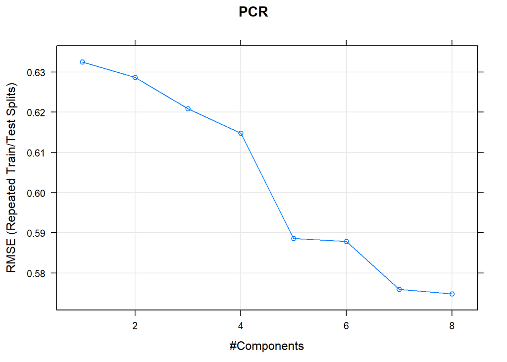

```r
set.seed(1)
pcrmodel1 <- train(
  life_ladder~., data = df, method = "pcr",
  preProcess=c("center", "scale"),
  trControl = trainControl("LGOCV", number = 10)
  ,tuneLength = 9
  )
plot(pcrmodel1,main="PCR")
```

```r
pcrmodel1$bestTune
```

```
##   ncomp
## 8     8
```

```r
min(pcrmodel1$results$RMSE)^2
```

```
## [1] 0.3304539
```

```r
#biplot(pcrmodel$finalModel)
#0.3304539
```

Through LGOCV, we found the minimal cross validation MSE for PCR is 0.3305 when the model includes 8 principal components.

# Partial least square regression

```r
set.seed(1)
pls_model2=train(life_ladder~.,data= df,
                 method = "pls",
                 preProcess=c("center", "scale"),
                 trControl = trainControl(method = "LGOCV",verboseIter=T,number=10), tuneLength = 9 )
min(pls_model2$results$RMSE)^2
```

```
## [1] 0.329472
```

```r
pls_model2$bestTune
```

```
##   ncomp
## 6     6
```

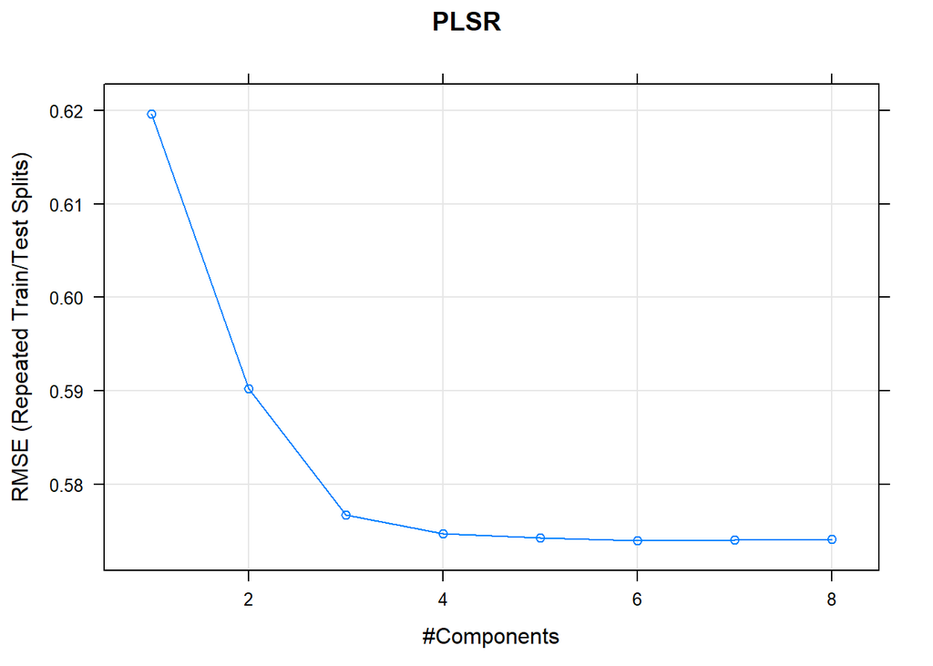

```r
plot(pls_model2,main ="PLSR")
```

```r
# 0.329472
```

Through LGOCV, we found the minimal cross validation MSE for PLSR is 0.3295 when the model includes 6 PLS components. PLSR has less component and shows lower CV MSE compared with PCR. This is because PLSR chooses components with regard to both maximal variance and the correlation with the response, whereas PCR only selects principal components based on maximal variance.

# Random forest

```r
set.seed(1)
rf_model=train(life_ladder~.,data= df,
                 method = "rf",
                 preProcess=c("center", "scale"),
                 trControl = trainControl(method = "LGOCV",verboseIter=T,number=10 ), tuneLength = 5 )
min(rf_model$results$RMSE)^2
```

```
## [1] 0.1718519
```

```r
rf_model$bestTune
```

```
##   mtry
## 2    3
```

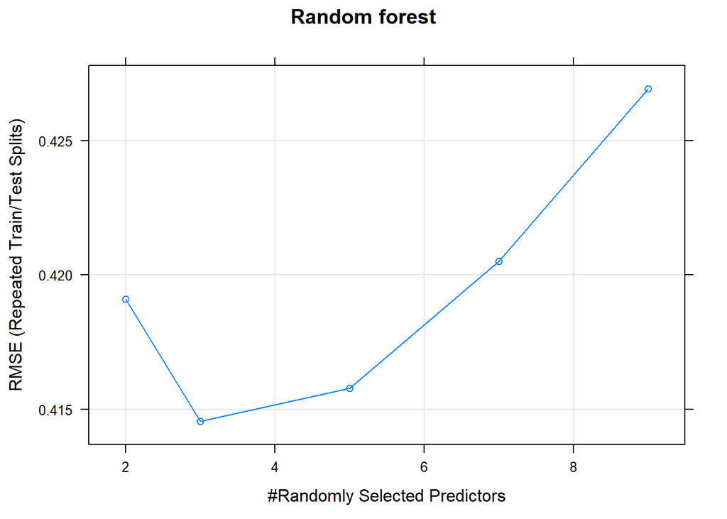

```r
plot(rf_model, main ="Random forest")
```

```r
# 0.1718519
```

Through LGOCV, we found the minimal cross validation MSE for random forest is 0.1719 when each tree has 3 predictors.

# Gradient Boosting Machine

```r
gbmgrid=expand.grid(interaction.depth = c(1,3,5),
                        n.trees = (2:30)*150,
                        shrinkage = c(0.01,0.001),
                        n.minobsinnode = 10)
set.seed(1)
boost_model=train(life_ladder~.,data= df,
                 method = "gbm",
                 preProcess=c("center", "scale"),
                 trControl = trainControl(method = "LGOCV",verboseIter=T,number=10), tuneGrid=gbmgrid )
min(boost_model$results$RMSE)^2
```

```
## [1] 0.1903925
```

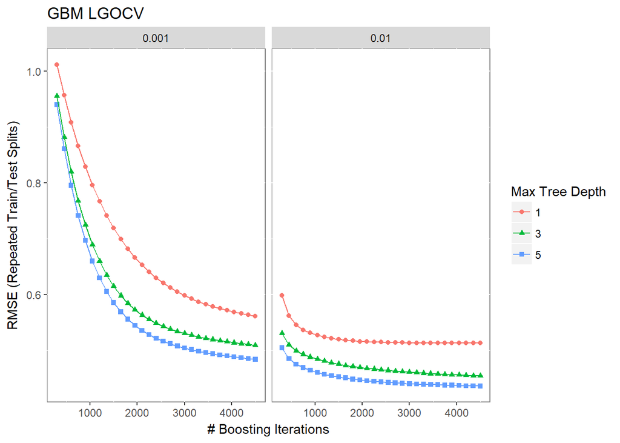

```r
ggplot(boost_model)+
  theme(panel.background = element_rect(fill = "white", colour = "grey50"))+
  labs(title="GBM LGOCV")
```

```r
boost_model$bestTune
```

```
##     n.trees interaction.depth shrinkage n.minobsinnode
## 174    4500                 5      0.01             10
```

```r
# 0.1903925
```

Through LGOCV, we found the minimal cross validation MSE for GBM is 0.1904 when the model has 4500 trees, each tree has 5 splits, and the shrinkage parameter is 0.01.

# Bagging trees

```r
set.seed(1)
bag_model=train(life_ladder~.,data= df,
                 method = "treebag",
                 preProcess=c("center", "scale"),
                 trControl = trainControl(method = "LGOCV",verboseIter=T,number=10 ) )
bag_model$results[2]^2
```

```
##        RMSE
## 1 0.2945061
```

```r
# 0.2945061
```

Through LGOCV, we found the minimal cross validation MSE for bagging trees is 0.2945.

# Bagging MARS

```r
set.seed(1)
bagmars_model=train(life_ladder~.,data= df,
                 method = "bagEarth",
                 preProcess=c("center", "scale"),
                 trControl = trainControl(method = "LGOCV",verboseIter=T,number=10 ), tuneLength = 5 )
min(bagmars_model$results$RMSE)^2
```

```
## [1] 0.2750501
```

```r
bagmars_model$bestTune
```

```
##   nprune degree
## 4     13      1
```

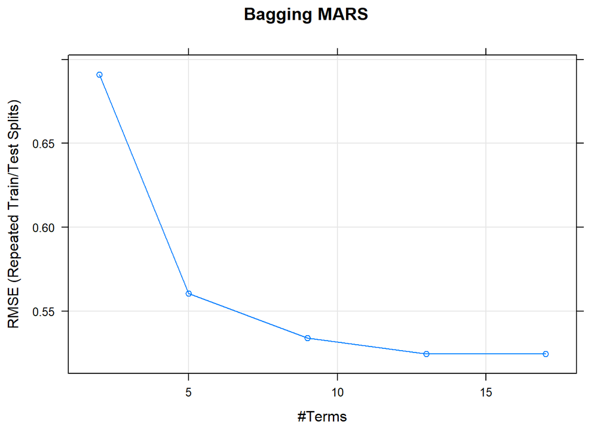

```r
plot(bagmars_model, main="Bagging MARS")
```

```r
#0.2750501
```

Through LGOCV, the minimal cross validation MSE for bagging MARS is 0.2751 with nprune=13 and degree=1.

# Boosted GAM

```r
set.seed(1)
gamboost_model=train(life_ladder~.,data= df,
                 method = "gamboost",
                 preProcess=c("center", "scale"),
                 trControl = trainControl(method = "LGOCV",verboseIter=T,number=10 ), tuneLength = 5 )
```

[output not shown]

[output not shown]

[output not shown]

[output not shown]

[output cut: 60 more lines]

[output not shown]

[output not shown]

[output cut: 60 more lines]

[output not shown]

[output not shown]

[output cut: 20 more lines]

[output not shown]

[output not shown]

[output not shown]

[output cut: 20 more lines]

[output not shown]

[output not shown]

[output cut: 24 more lines]

[output not shown]

```r
min(gamboost_model$results[3])^2
```

```
## [1] 0.2826903
```

```r
gamboost_model$bestTune
```

```
##   mstop prune
## 5   250    no
```

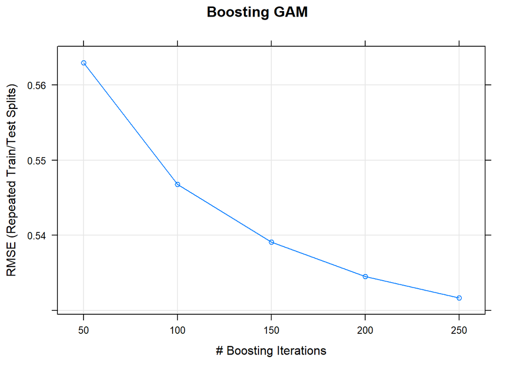

```r
plot(gamboost_model, main="Boosting GAM")
```

```r
#0.2826903
```

Through LGOCV, the minimal cross validation MSE for Boosted GAM is 0.2827.

# K-nearest neighbours

```r
set.seed(1)
knnmod <- train(life_ladder ~ ., data = df,
             method = "knn",
             preProcess=c("center", "scale"),
             tuneLength = 12,
             trControl = trainControl(method = "LGOCV",verboseIter=T,number=10))
min(knnmod$results$RMSE)^2
```

```
## [1] 0.1811445
```

```r
knnmod$bestTune
```

```
##   k
## 1 5
```

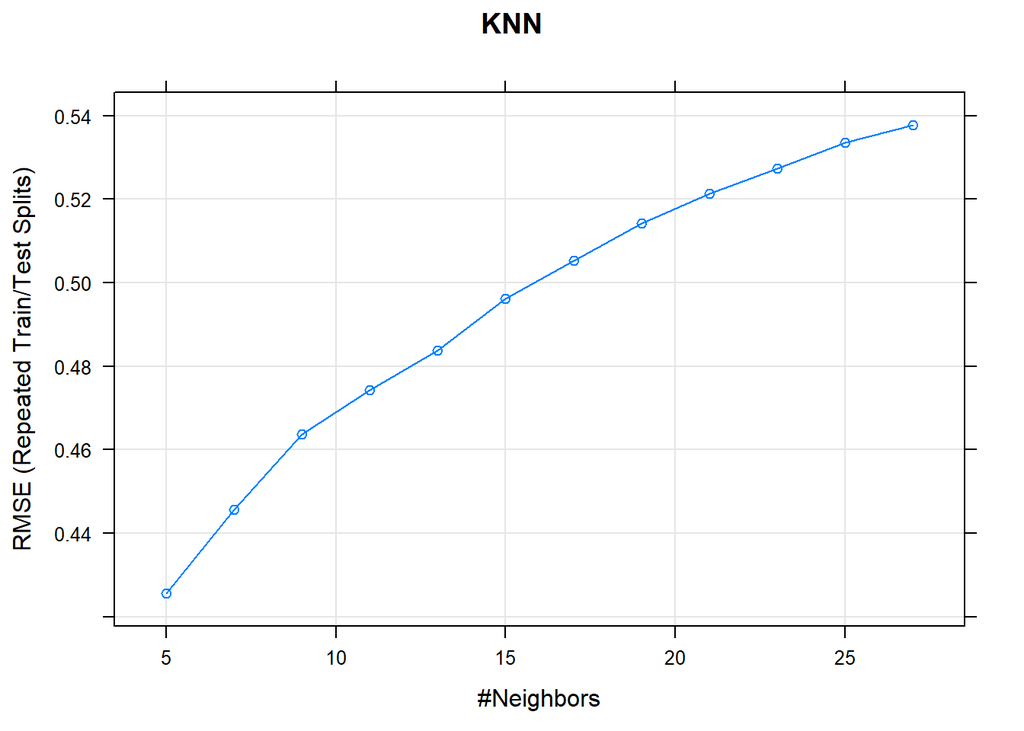

```r
plot(knnmod,main="KNN")
```

```r
#0.1811445
```

Through LGOCV, the minimal cross validation MSE for KNN is 0.1811 when K is 5.

# Support vector machine

```r
set.seed(1)
svmmod <- train(life_ladder ~ ., data = df,
             method = "svmLinear3",
             preProcess=c("center", "scale"),
             trControl = trainControl(method = "LGOCV",verboseIter=T,number=10))
min(svmmod$results$RMSE)^2
```

```
## [1] 0.3297699
```

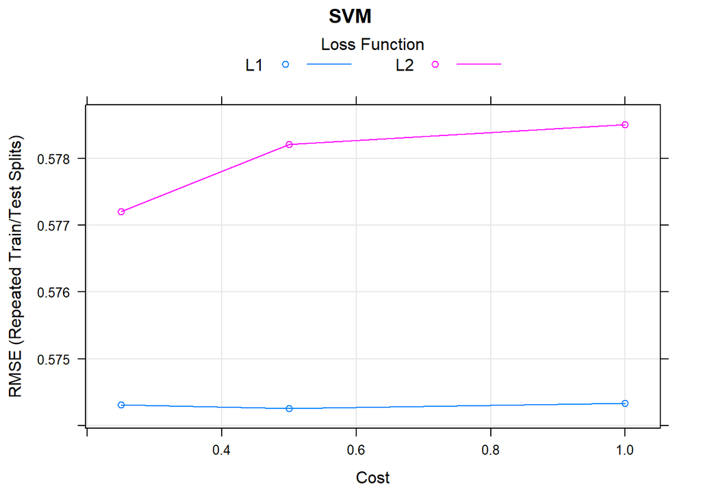

```r
plot(svmmod, main="SVM")
```

```r
svmmod$bestTune
```

```
##   cost Loss
## 3  0.5   L1
```

```r
#0.3297699
```

Through LGOCV, the minimal cross validation MSE for SVM is 0.3298 when cost is 0.5 and when L1 loss is used.

# Model comparison

For the 10 models above, we use resamples function to compare their performance.

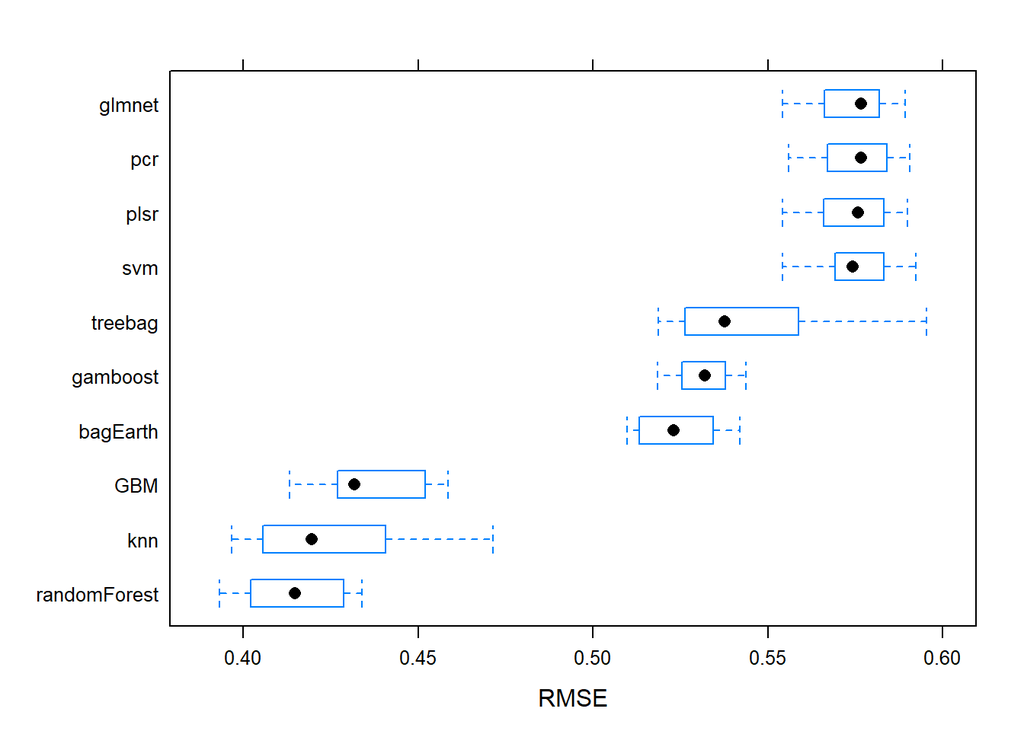

```r
resamp <- resamples(list( plsr = pls_model2, pcr = pcrmodel1,glmnet=glmnetmodel2,GBM=boost_model,gamboost=gamboost_model,randomForest=rf_model,bagEarth=bagmars_model,treebag=bag_model, knn=knnmod, svm=svmmod))
bwplot(resamp, metric = "RMSE")
```

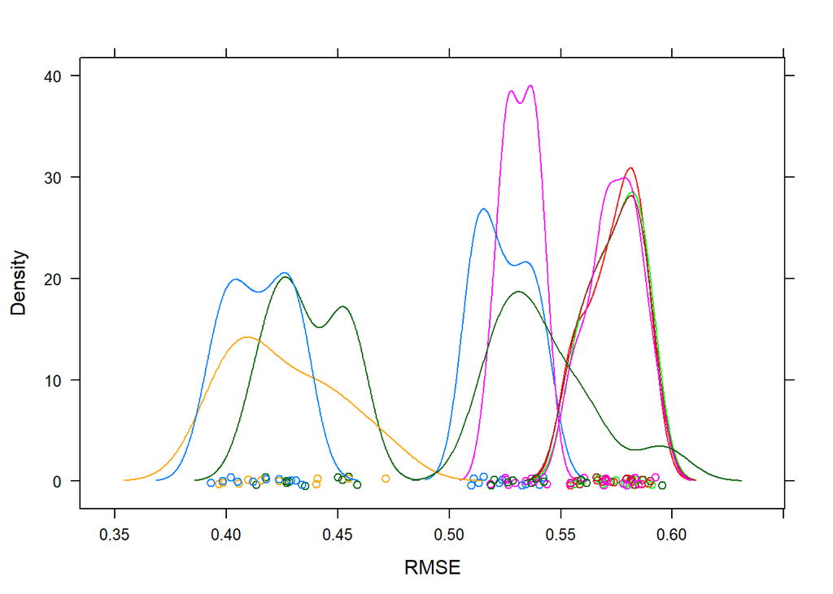

```r
densityplot(resamp, metric = "RMSE")
```

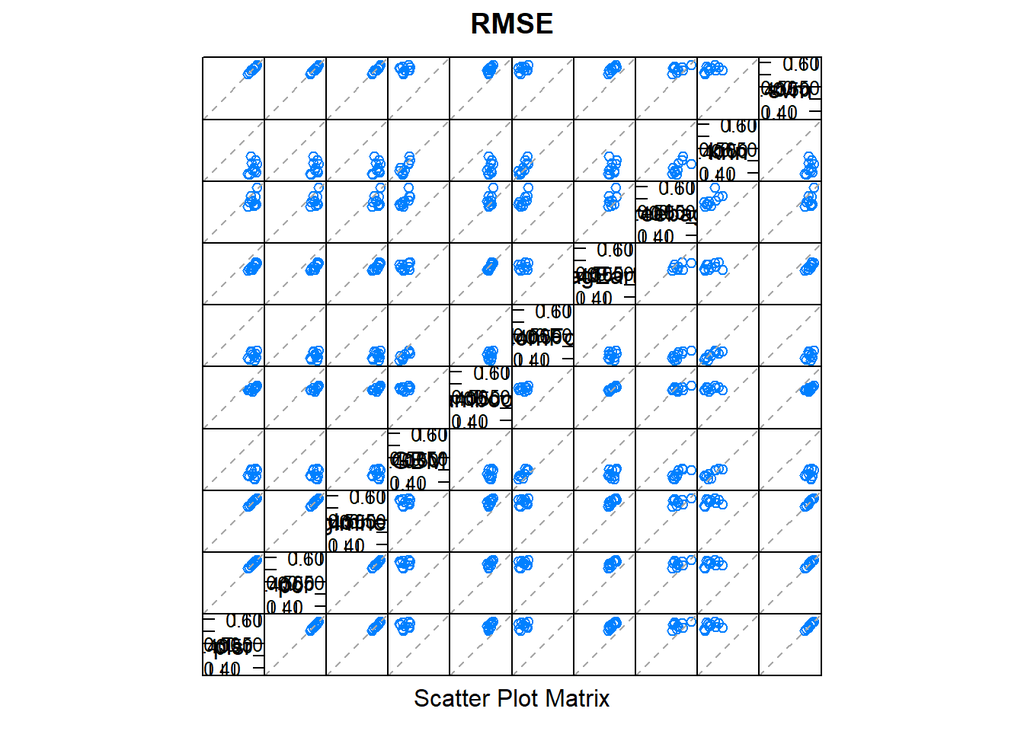

```r
splom(resamp, metric = "RMSE")
```

```r
diff1=diff(resamp)
summary(diff1)
```

```
##
## Call:
## summary.diff.resamples(object = diff1)
##
## p-value adjustment: bonferroni
## Upper diagonal: estimates of the difference
## Lower diagonal: p-value for H0: difference = 0
##
## MAE
##              plsr      pcr        glmnet     GBM        gamboost
## plsr                   -0.0007324 -0.0003999  0.1122720  0.0296386
## pcr          1.0000000             0.0003325  0.1130044  0.0303710
## glmnet       1.0000000 1.0000000              0.1126719  0.0300385
## GBM          1.342e-07 1.694e-07  1.013e-07             -0.0826334
## gamboost     0.0002220 0.0002423  0.0001433  1.247e-07
## randomForest 8.709e-09 1.292e-08  6.315e-09  0.0010436  5.103e-09
## bagEarth     6.721e-06 7.364e-06  5.488e-06  3.192e-06  1.0000000
## treebag      0.1765245 0.1733642  0.1404526  5.865e-07  1.0000000
## knn          6.668e-08 9.177e-08  5.593e-08  0.6368032  6.577e-07
## svm          0.0604701 1.0000000  0.2740721  7.037e-08  8.454e-05
##              randomForest bagEarth   treebag    knn        svm
## plsr          0.1306708    0.0349379  0.0207971  0.1222575 -0.0021181
## pcr           0.1314033    0.0356703  0.0215295  0.1229899 -0.0013856
## glmnet        0.1310707    0.0353378  0.0211970  0.1226574 -0.0017182
## GBM           0.0183988   -0.0773341 -0.0914749  0.0099855 -0.1143901
## gamboost      0.1010323    0.0052993 -0.0088415  0.0926189 -0.0317566
## randomForest              -0.0957330 -0.1098737 -0.0084133 -0.1327889
## bagEarth     2.545e-07               -0.0141408  0.0873196 -0.0370559
## treebag      4.958e-08    1.0000000              0.1014604 -0.0229152
## knn          1.0000000    3.866e-06  1.975e-06             -0.1243756
## svm          4.082e-09    3.282e-06  0.0613518  4.071e-08
##
## RMSE
##              plsr      pcr        glmnet     GBM        gamboost
## plsr                   -8.546e-04  5.375e-07  1.377e-01  4.231e-02
## pcr          0.2949444             8.552e-04  1.385e-01  4.316e-02
## glmnet       1.0000000 1.0000000              1.377e-01  4.231e-02
## GBM          1.662e-07 1.458e-07  1.725e-07             -9.535e-02
## gamboost     3.694e-06 3.122e-06  4.535e-06  6.577e-07
## randomForest 9.422e-09 8.785e-09  8.860e-09  0.0004927  4.868e-08
```

[output cut: 24 more lines]

```
## bagEarth     1.782e-07 1.703e-07  3.156e-07  5.906e-06  0.2256435
## treebag      0.0957922 0.0776863  0.1071301  2.868e-06  1.0000000
## knn          9.079e-07 8.769e-07  9.195e-07  1.0000000  7.598e-06
## svm          1.0000000 1.0000000  1.0000000  1.319e-07  3.151e-06
##              randomForest bagEarth   treebag    knn        svm
## plsr         -1.201e-01   -4.044e-02 -2.626e-02 -1.111e-01  2.439e-04
## pcr          -1.208e-01   -4.121e-02 -2.703e-02 -1.119e-01 -5.253e-04
## glmnet       -1.200e-01   -4.042e-02 -2.624e-02 -1.111e-01  2.636e-04
## GBM          -1.610e-02    6.352e-02  7.770e-02 -7.168e-03  1.042e-01
## gamboost     -8.504e-02   -5.431e-03  8.749e-03 -7.611e-02  3.525e-02
## randomForest               7.961e-02  9.379e-02  8.930e-03  1.203e-01
## bagEarth     5.075e-07                1.418e-02 -7.068e-02  4.068e-02
## treebag      7.225e-07    1.0000000             -8.486e-02  2.650e-02
## knn          0.9365299    3.862e-05  4.827e-06              1.114e-01
## svm          1.075e-08    4.081e-08  0.0670608  7.232e-07
```

From resampling, we can see that random forest has the best prediction of life ladder values among the 10 methods, followed by KNN and GBM. The medium performance models includes boosted GAM, bagging tree, and bagging MARS. Lastly, in predicting life ladder values, PCR, PLSR, elastic net, and SVM have similar MSEs, which are higher than other models. From the density plot, we can see that the boosted GAM has the smallest variability.

After fitting the regression model with full dataset, we also splitted the data into training set and test set to fit regression and classification models.

# regression tree

```r
set.seed(1)
index <- createDataPartition(df$life_ladder, p=0.75, list=FALSE)
train_data <- df[index,]
test_data <- df[-index,]
```

Separate data set into train set and validation set in 3:1.

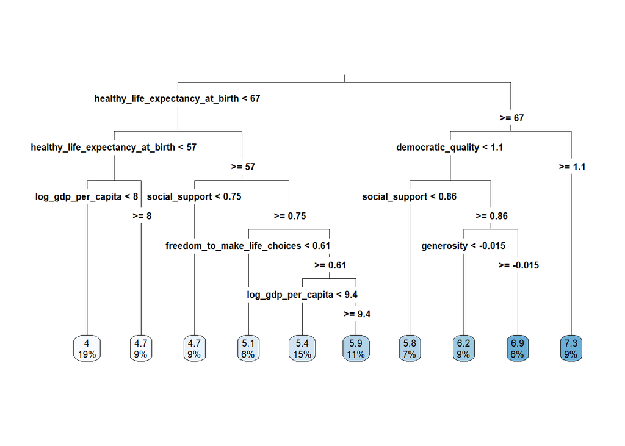

```r
rpart.df <- rpart(life_ladder~log_gdp_per_capita+social_support+healthy_life_expectancy_at_birth+freedom_to_make_life_choices+generosity+perceptions_of_corruption+confidence_in_national_government+democratic_quality+delivery_quality, method="anova",data=train_data)
rpart.plot(rpart.df,type=3)
```

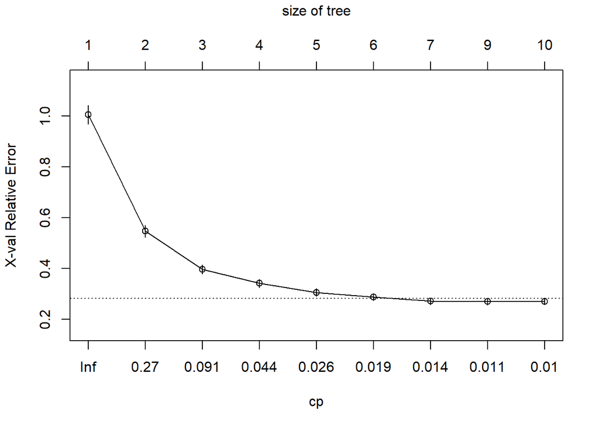

```r
plotcp(rpart.df)#choose cp=0.014
```

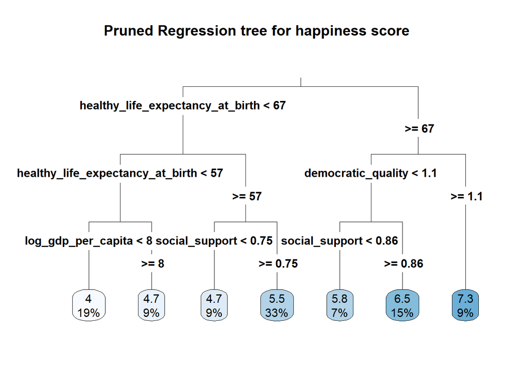

```r
#prune
pfit<- prune(rpart.df, cp=0.014)
rpart.plot(pfit,type=3,main="Pruned Regression tree for happiness score")
```

```r
pred <- predict(pfit,test_data)
mean((pred - test_data$life_ladder)^2)  #0.315
```

```
## [1] 0.3151165
```

Choose size=7 and cp=0.014,we get a prune tree with 7 terminal nodes and their means.  
The test error is 0.315.

# bagging

```r
set.seed(2)
bag_df <- randomForest(life_ladder~log_gdp_per_capita+social_support+healthy_life_expectancy_at_birth+freedom_to_make_life_choices+generosity+perceptions_of_corruption+confidence_in_national_government+democratic_quality+delivery_quality, data = train_data,mtry = 9, importance =TRUE)
importance(bag_df) #Health and social support and GPA are most important
```

```
##                                    %IncMSE IncNodePurity
## log_gdp_per_capita                28.06085     194.27038
## social_support                    52.07928      98.49117
## healthy_life_expectancy_at_birth  51.23917     620.52870
## freedom_to_make_life_choices      34.32303      34.36839
## generosity                        29.85212      33.88342
## perceptions_of_corruption         31.82752      35.47063
## confidence_in_national_government 31.51671      30.97097
## democratic_quality                39.92165      78.91264
## delivery_quality                  26.38854      36.99406
```

```r
pred_df <- predict(bag_df,test_data)
mean((pred_df - test_data$life_ladder)^2) #test error=0.156
```

```
## [1] 0.1555077
```

Using bagging and we found that the three most important variables are healthy life expectancy at birth, GDP and social support. These three factors all have positive association with happiness scores.  
The test error is 0.156.

# boosting

```r
train_control <- trainControl(method="cv", number=10)
# fix the parameters of the algorithm
grid <- expand.grid(n.trees=c(50,100,500,1000), #tuning parameter
                    shrinkage=c(0.01,0.05,0.1,0.5),
                    interaction.depth=c(2,4),
                    n.minobsinnode = c(10))
# train the model
set.seed(2)
model <- train(life_ladder~.,
               train_data,
               trControl=train_control,
               method="gbm",
               tuneGrid=grid,
               preProcess = c("center","scale"),
               verbose = FALSE)
# summarize results
print(model)
```

```
## Stochastic Gradient Boosting
##
## 889 samples
##   9 predictor
##
## Pre-processing: centered (9), scaled (9)
## Resampling: Cross-Validated (10 fold)
## Summary of sample sizes: 798, 798, 800, 801, 801, 801, ...
## Resampling results across tuning parameters:
##
##   shrinkage  interaction.depth  n.trees  RMSE       Rsquared   MAE
##   0.01       2                    50     0.8878727  0.7179593  0.7318826
##   0.01       2                   100     0.7368370  0.7429808  0.6031816
##   0.01       2                   500     0.5255601  0.7933141  0.4141758
##   0.01       2                  1000     0.5045265  0.8085002  0.3977677
##   0.01       4                    50     0.8487680  0.7628295  0.6997493
##   0.01       4                   100     0.6850566  0.7772798  0.5590603
##   0.01       4                   500     0.4921491  0.8187093  0.3873407
##   0.01       4                  1000     0.4740064  0.8314135  0.3733228
##   0.05       2                    50     0.5706943  0.7722368  0.4578096
##   0.05       2                   100     0.5266714  0.7921759  0.4153163
##   0.05       2                   500     0.4946142  0.8161129  0.3915081
##   0.05       2                  1000     0.4849279  0.8234514  0.3856505
##   0.05       4                    50     0.5283712  0.8016712  0.4210924
##   0.05       4                   100     0.4916148  0.8191487  0.3860563
##   0.05       4                   500     0.4556537  0.8440695  0.3592368
##   0.05       4                  1000     0.4459091  0.8507905  0.3505357
##   0.10       2                    50     0.5271165  0.7917236  0.4154926
##   0.10       2                   100     0.5100506  0.8039739  0.4025271
##   0.10       2                   500     0.4874913  0.8213683  0.3874063
##   0.10       2                  1000     0.4818393  0.8257059  0.3796672
##   0.10       4                    50     0.4900607  0.8209903  0.3849618
##   0.10       4                   100     0.4751501  0.8309908  0.3744096
##   0.10       4                   500     0.4527005  0.8464683  0.3566325
##   0.10       4                  1000     0.4457754  0.8511253  0.3502947
##   0.50       2                    50     0.5272828  0.7917670  0.4133631
##   0.50       2                   100     0.5228805  0.7965322  0.4109964
##   0.50       2                   500     0.5238648  0.7995826  0.4104231
##   0.50       2                  1000     0.5218797  0.8002773  0.4105999
##   0.50       4                    50     0.5235178  0.7961719  0.4085613
##   0.50       4                   100     0.5396433  0.7862586  0.4236736
##   0.50       4                   500     0.5434204  0.7859155  0.4251008
##   0.50       4                  1000     0.5455632  0.7845148  0.4274736
##
## Tuning parameter 'n.minobsinnode' was held constant at a value of 10
## RMSE was used to select the optimal model using the smallest value.
## The final values used for the model were n.trees = 1000,
##  interaction.depth = 4, shrinkage = 0.1 and n.minobsinnode = 10.
```

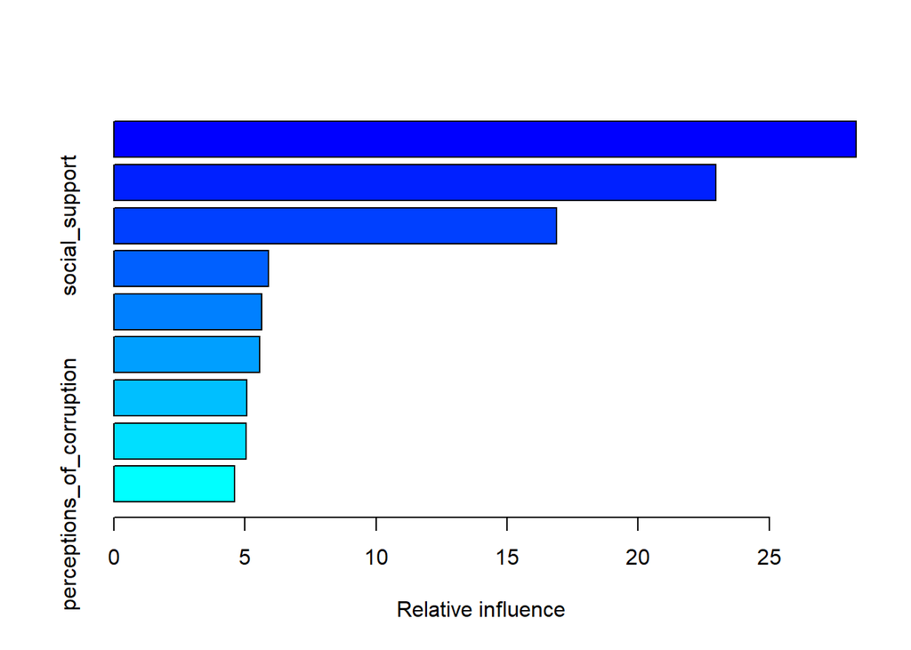

```
##                                                                 var
## healthy_life_expectancy_at_birth   healthy_life_expectancy_at_birth
## log_gdp_per_capita                               log_gdp_per_capita
## social_support                                       social_support
## democratic_quality                               democratic_quality
## confidence_in_national_government confidence_in_national_government
## freedom_to_make_life_choices           freedom_to_make_life_choices
## generosity                                               generosity
## delivery_quality                                   delivery_quality
## perceptions_of_corruption                 perceptions_of_corruption
##                                     rel.inf
## healthy_life_expectancy_at_birth  28.317688
## log_gdp_per_capita                22.958925
## social_support                    16.898625
## democratic_quality                 5.892802
## confidence_in_national_government  5.647628
## freedom_to_make_life_choices       5.558858
## generosity                         5.073644
## delivery_quality                   5.049402
## perceptions_of_corruption          4.602429
```

```r
summary(model) #healthy, gdp,social
```

```r
pred_1 <- predict(model,test_data)
mean((pred_1 - test_data$life_ladder)^2) #0.20
```

```
## [1] 0.2043669
```

Using boosting for scaled and center data, we found that the three most important variables are healthy life expectancy at birth,GDP and social support. These three factors all have positive association with happiness scores.  
The test error is 0.20.

# rf

```r
set.seed(2)
model_rf<-train(life_ladder~.,
                train_data,
                importance=TRUE,
                method='rf',
                trControl=train_control
                )
print(model_rf)
```

```
## Random Forest
##
## 889 samples
##   9 predictor
##
## No pre-processing
## Resampling: Cross-Validated (10 fold)
## Summary of sample sizes: 798, 798, 800, 801, 801, 801, ...
## Resampling results across tuning parameters:
##
##   mtry  RMSE       Rsquared   MAE
##   2     0.4208632  0.8699682  0.3266863
##   5     0.4126726  0.8732001  0.3195410
##   9     0.4195858  0.8683351  0.3264887
##
## RMSE was used to select the optimal model using the smallest value.
## The final value used for the model was mtry = 5.
```

```r
varImp(model_rf)
```

```
## rf variable importance
##
##                                   Overall
## healthy_life_expectancy_at_birth   100.00
## social_support                      96.42
## democratic_quality                  77.45
## freedom_to_make_life_choices        66.38
## log_gdp_per_capita                  55.36
## generosity                          51.73
## confidence_in_national_government   48.22
## perceptions_of_corruption           40.96
## delivery_quality                     0.00
```

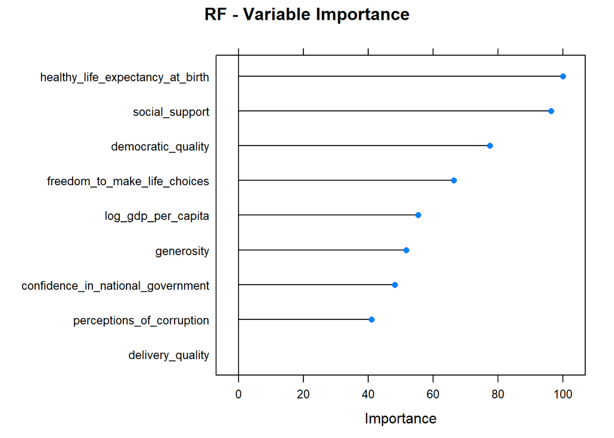

```r
plot(varImp(object=model_rf),
     main="RF - Variable Importance") #healthy,social,democratic
```

```r
pred_2 <- predict(model_rf,test_data)
mean((pred_2 - test_data$life_ladder)^2) #0.151
```

```
## [1] 0.151148
```

Using random forest and we found that the three most important variables are healthy life expectancy at birth,social support and democratic quality. These three factors all have positive association with happiness scores.  
The test error is 0.151.

During these ensembel methods for regression tree, random forest method has smallest test error so that it is the best method. The three most important variables for happiness scores are similar. Healthy life expectancy at birth is the most important variable and the larger average equivalent number of years of full health that a newborn could expect to live,the higher happiness score will the people have. Higher GDP, complete social support and high democratic quality will bring people happiness.  
We can see that money of the country is not the most important factor of happiness but it still is a key point.Health and social support play a important part in people’s happiness life.